# ABPCameraDesign

Mathieu Pruvot

2023-01-31

Load and plot data

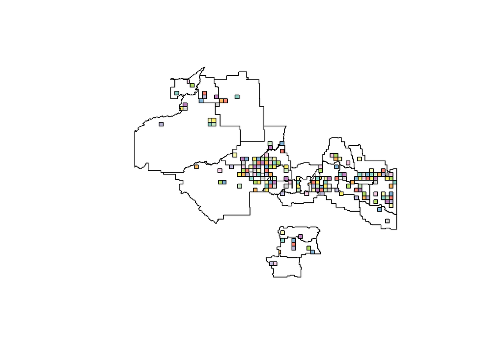

```r
plot(st_geometry(counties))
plot(hotcore[1],add=T)
```

overall farm size distribution

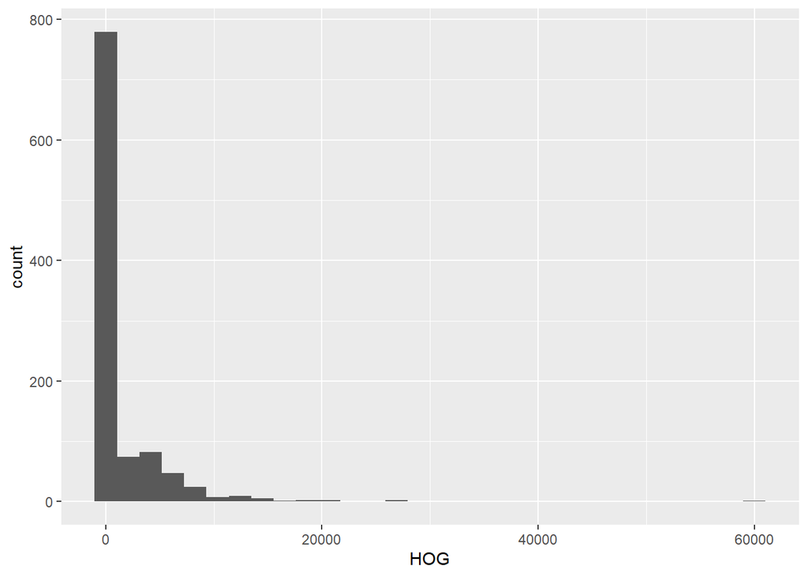

```r
ABP %>%
ggplot(aes(x=HOG))+
  geom_histogram()
```

identify ABP intersecting with county and show size distribution

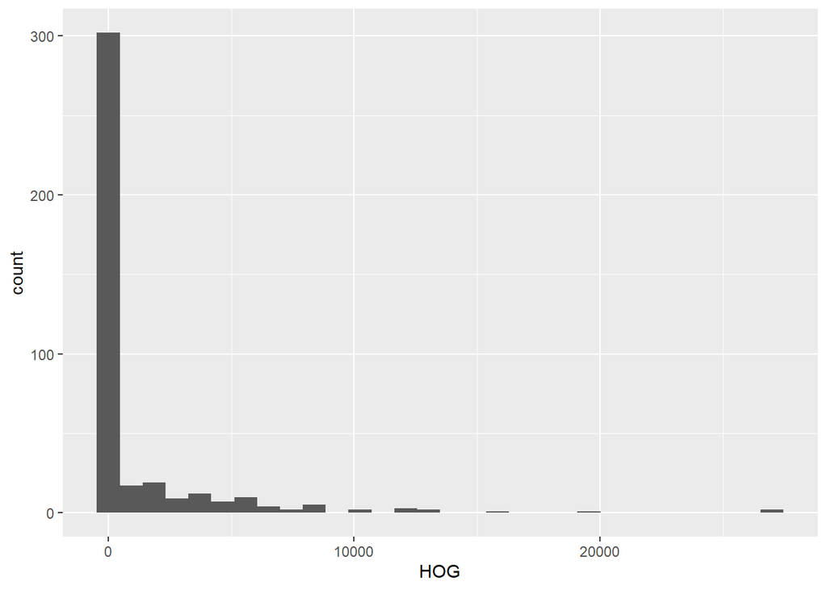

```r
ABP %>%
st_intersection(counties) %>%
ggplot(aes(x=HOG))+
  geom_histogram()
```

identify ABP intersecting with core area and show size distribution

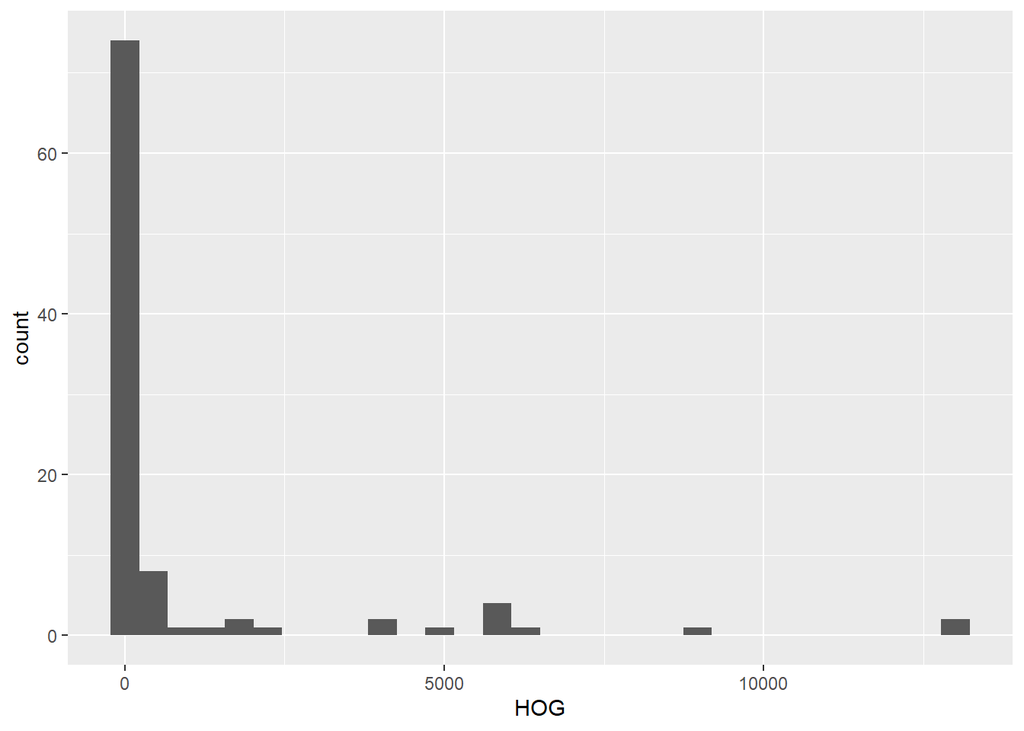

```r
ABP %>%
st_intersection(hotcore) %>%
ggplot(aes(x=HOG))+
  geom_histogram()
```

# Farm selection

Design scheme: we initially deploy 100 cameras, with the following stratification:

- 15 outdoor and 85 indoor
- among 85: 65 in core area and 20 in broader counties
- among the 65 core cameras: 15 in commercial farms, 50 in backyard farms
- among the 50 : stratify by county, distribute according to size distribution

Outdoor farms: get all 15 outdoor farms in the counties, regardless of size and location

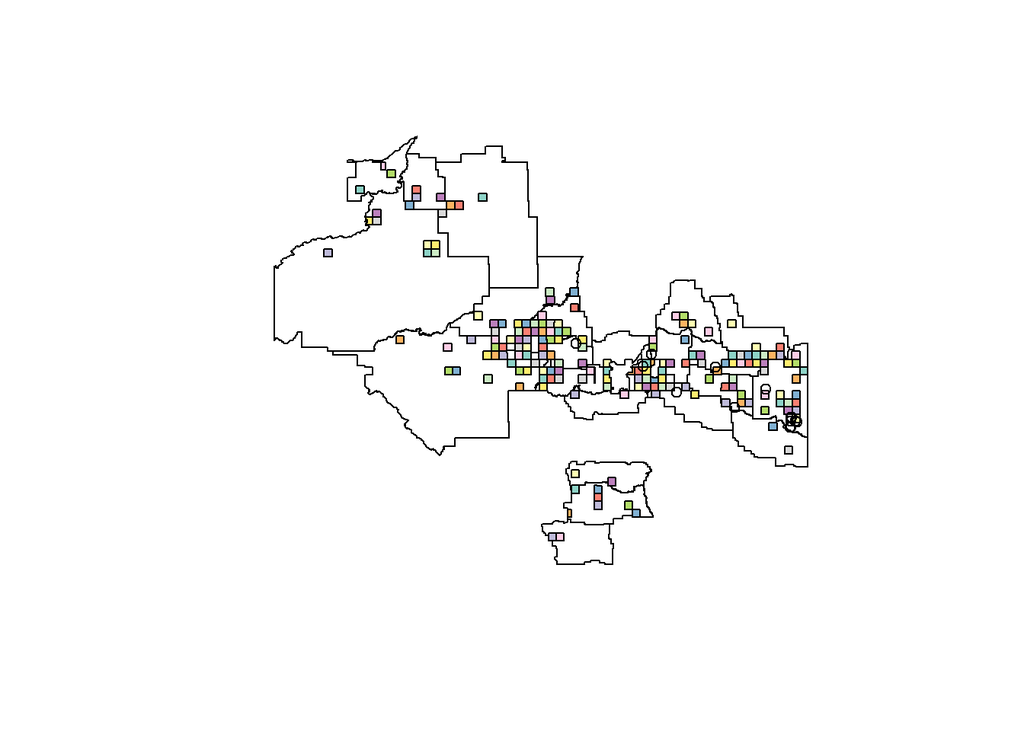

```r
Sample_OutdoorFarm <- ABP %>%
st_intersection(st_union(counties))%>%
  st_join(y=counties) %>%
  filter(Pigs_Have=="Yes")

plot(st_geometry(counties))
plot(hotcore[1],add=T)
plot(st_geometry(Sample_OutdoorFarm),add=T)
```

15 total in the counties

```r
Sample_OutdoorFarm %>%
st_intersection(st_union(hotcore))%>%
  tabyl(CQA_Status)
```

```
##  CQA_Statusgeometry n percent
##       Not Validated 3    0.75
##             Overdue 1    0.25
```

4 in the core area this means 11 outside core, including 3 commercials

Select 1 smallholder farm (CQA_Status Not validated) per county that was inside the county but outside core area and the furthest away from the core area, for a total of 20 farms. We excluded Strathcona county, which had extensive coverage by core area (limited additional information to sample county outside of core area)

```r
FarmInCounty <- ABP %>%
st_intersection(st_difference(st_geometry(counties),st_union(hotcore)))%>%
  st_join(y=counties) %>%
  filter(Pigs_Have=="No" & !GEONAME%in% c("STRATHCONA COUNTY") & CQA_Status=="Not Validated")

Sample_FarmInCounty <- ABP %>%
st_intersection(st_difference(st_geometry(counties),st_union(hotcore)))%>%
  st_join(y=counties) %>%
  filter(!Pigs_Have=="Yes" & !GEONAME%in% c("STRATHCONA COUNTY") & CQA_Status=="Not Validated") %>%
  mutate(distcore=st_distance(x=.,y=st_union(hotcore))) %>%
  group_by(GEONAME) %>%
  arrange(desc(distcore)) %>%
  slice(1) %>%
  select(-distcore)
```

Control that the most remote was selected by comparing selected map and map of smallholder in county outside core

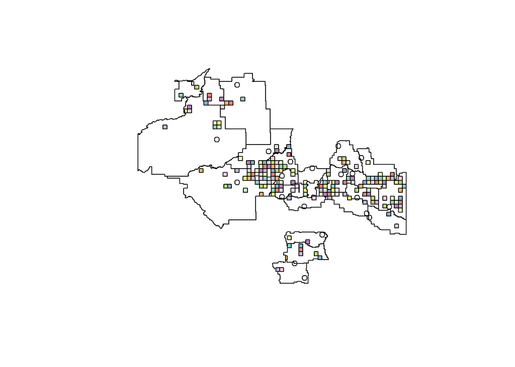

```r
plot(st_geometry(counties))
plot(hotcore[1],add=T)
plot(st_geometry(Sample_FarmInCounty),add=T)
```

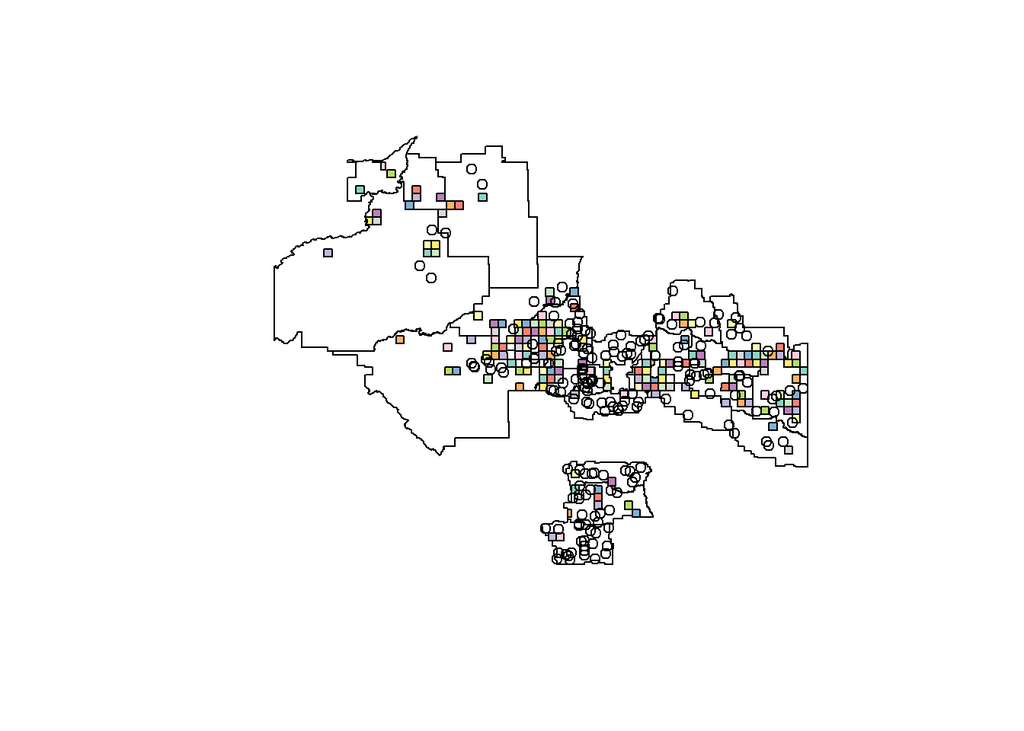

```r
plot(st_geometry(counties))
plot(hotcore[1],add=T)
plot(st_geometry(FarmInCounty),add=T)
```

among the 65 core cameras: 15 in commercial farms

Not enough commercial farms in core area, so used a 10k buffer around core

```r
CommFarmInCore <- ABP %>%
st_intersection(st_buffer(st_union(hotcore),dist=10000))%>%
  st_join(y=counties) %>%
  filter(!Pigs_Have=="Yes" & CQA_Status %in% c("Valid"))


Sample_CommFarmInCore <- CommFarmInCore %>%
  group_by(GEONAME) %>%
  sample_n(size=1)
```

This resulted in 12 commercial farms

Here is the map

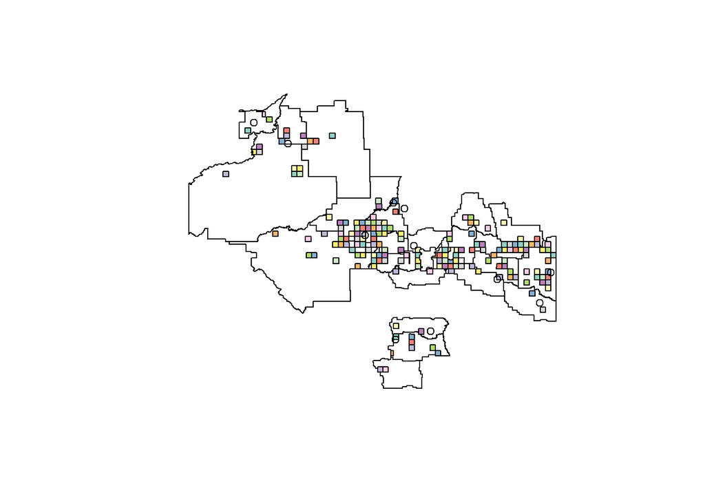

```r
plot(st_geometry(counties))
plot(hotcore[1],add=T)
plot(st_geometry(Sample_CommFarmInCore),add=T)
```

Look at number of large farms per county and identify the 4 counties with the most large farms

```r
ManyCommFarm <- CommFarmInCore %>%
  group_by(GEONAME) %>%
  summarize(n=n()) %>%
  arrange(desc(n)) %>%
  filter(!is.na(GEONAME)) %>%
  slice(1:4) %>%
  select(GEONAME) %>%
  as.data.frame() %>%
  select(GEONAME)

ManyCommFarm
```

```
##                                   GEONAME
## 1                          LACOMBE COUNTY
## 2                         RED DEER COUNTY
## 3 MUNICIPAL DISTRICT OF WAINWRIGHT NO. 61
## 4               COUNTY OF BARRHEAD NO. 11
```

Select an additional 4 farms from counties that have the most farms and add to the previous selection

```r
Sample_CommFarmInCore <- CommFarmInCore %>%
  filter(GEONAME %in% ManyCommFarm$GEONAME & !Premises_I %in% Sample_CommFarmInCore$Premises_I) %>%
  group_by(GEONAME) %>%
  sample_n(size=1) %>%
  rbind(Sample_CommFarmInCore)
```

among the 50 smallholder in core: stratify by county, distribute according to size distribution

Select all indoor smallholder farms in the core

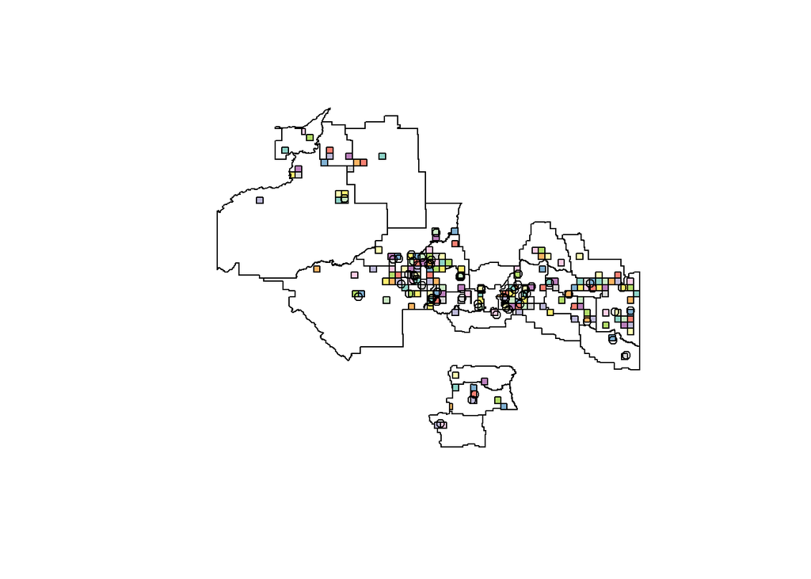

```r
SmallFarmInCore <- ABP %>%
st_intersection(st_union(hotcore))%>%
  st_join(y=counties) %>%
  filter(!Pigs_Have=="Yes" & CQA_Status=="Not Validated")


plot(st_geometry(counties))
plot(hotcore[1],add=T)
plot(st_geometry(SmallFarmInCore),add=T)
```

inspect size distribution. Take farms with HOG>2, because more relevant to pathogen transmission if not just isolated animals. Happens to provide 52 farms

```r
SmallFarmInCore %>%
  filter(HOG>2) %>%
  select(HOG) %>%
  summary()
```

```
##       HOG                   geometry
##  Min.   :    3.0   POINT        :52
##  1st Qu.:    9.0   epsg:4269    : 0
##  Median :   20.0   +proj=long...: 0
##  Mean   :  395.1
##  3rd Qu.:   50.0
##  Max.   :13000.0
```

```r
Sample_SmallFarmInCore <- SmallFarmInCore %>%
  filter(HOG>2)
```

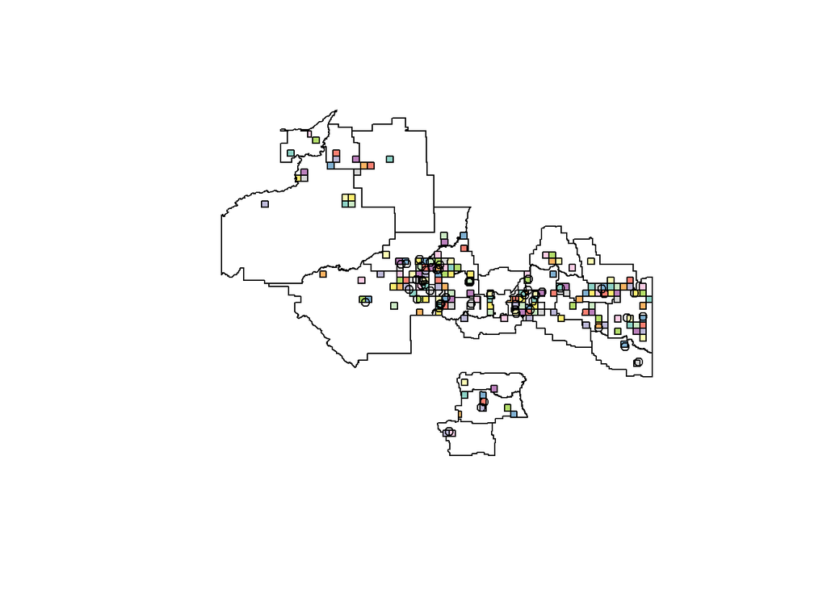

```r
plot(st_geometry(counties))
plot(hotcore[1],add=T)
plot(st_geometry(Sample_SmallFarmInCore),add=T)
```

```r
Sample_Total <- rbind(Sample_CommFarmInCore,Sample_FarmInCounty, Sample_OutdoorFarm, Sample_SmallFarmInCore)
#save(Sample_Total,file="Sample_Total.Rdata")
```

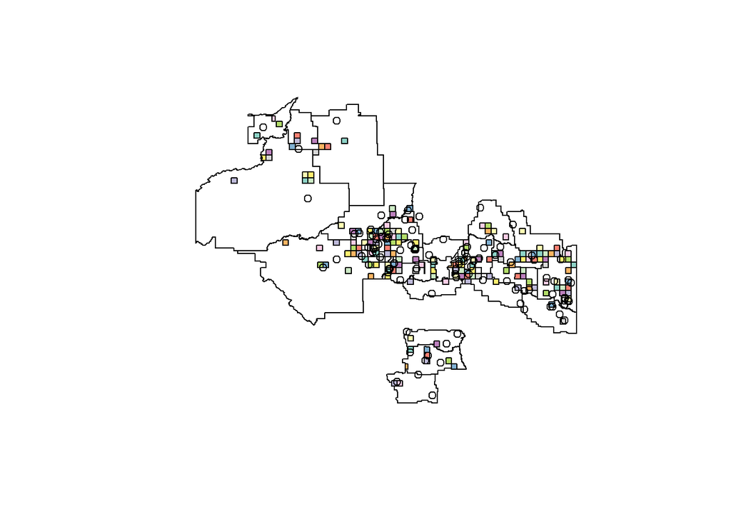

```r
plot(st_geometry(counties))
plot(hotcore[1],add=T)
plot(st_geometry(Sample_Total),add=T)
```